# Predict Bike Sharing Demand with AutoGluon Template

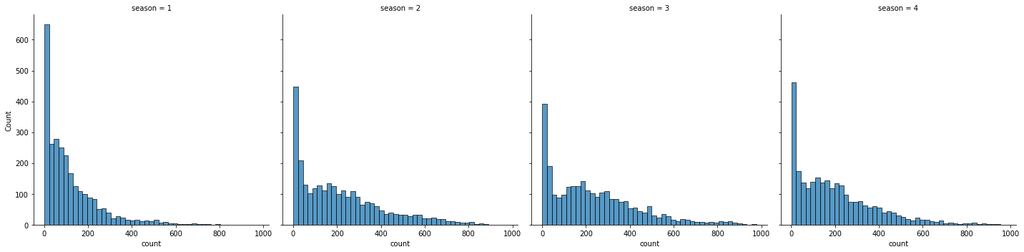

```python
sns.displot(data = trainPairDf, x = 'count', col = 'season')
```

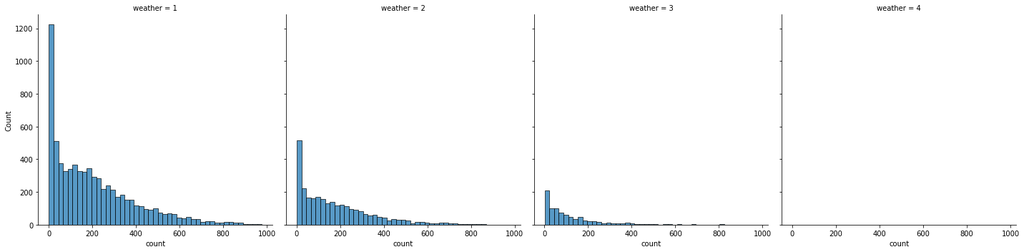

```python
sns.displot(data = trainPairDf, x = 'count', col = 'weather')
```

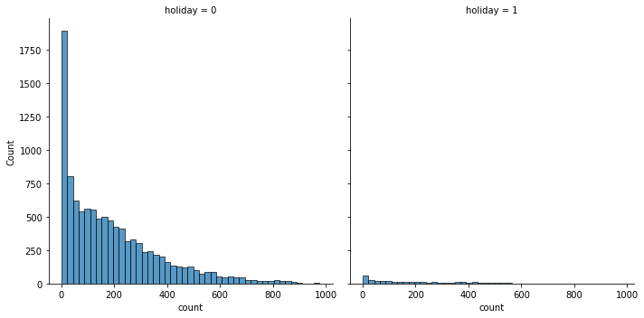

```python
sns.displot(data = trainPairDf, x = 'count', col = 'holiday')
```

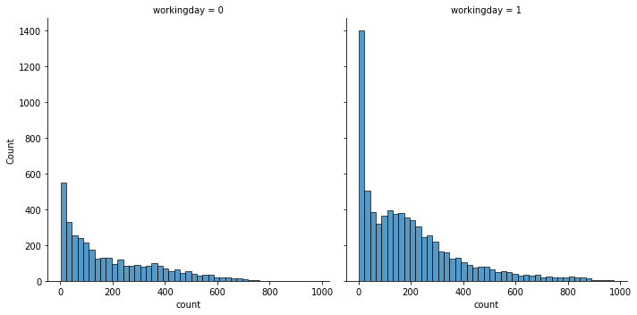

```python
sns.displot(data = trainPairDf, x = 'count', col = 'workingday')
```

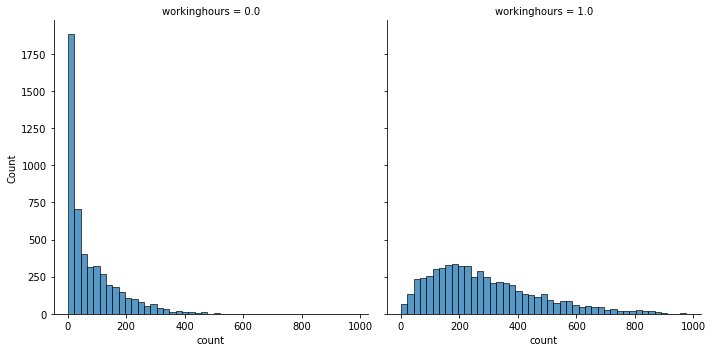

```python
sns.displot(data = trainPairDf, x = 'count', col = 'workinghours')
```

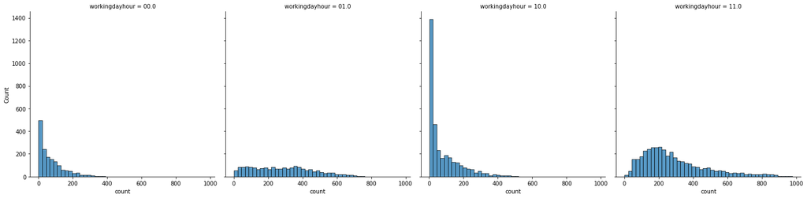

```python
sns.displot(data = trainPairDf, x = 'count', col = 'workingdayhour')
```

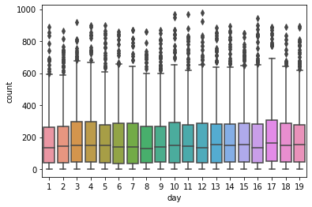

```python
sns.boxplot(data = trainPairDf, x = 'day', y = 'count')
```

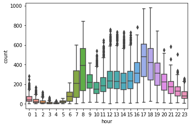

```python
sns.boxplot(data = trainPairDf, x = 'hour', y = 'count')
```

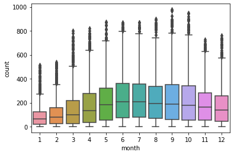

```python
sns.boxplot(data = trainPairDf, x = 'month', y = 'count')
```

## Step 5: Rerun the model with the same settings as before, just with more features

```python
predictor_new_features = TabularPredictor(
    label = 'count'
    , eval_metric = 'root_mean_squared_error'
).fit(
    train_data = train.drop(columns = ['casual', 'registered'])
    ,time_limit = 600
    , presets = 'best_quality'
)
```

```
No path specified. Models will be saved in: "AutogluonModels/ag-20221124_182807/"
Presets specified: ['best_quality']
Stack configuration (auto_stack=True): num_stack_levels=1, num_bag_folds=8, num_bag_sets=20
Beginning AutoGluon training ... Time limit = 600s
AutoGluon will save models to "AutogluonModels/ag-20221124_182807/"
AutoGluon Version:  0.6.0
Python Version:     3.7.10
Operating System:   Linux
Platform Machine:   x86_64
Platform Version:   #1 SMP Thu Sep 29 01:01:23 UTC 2022
Train Data Rows:    10886
Train Data Columns: 14
Label Column: count
Preprocessing data ...
AutoGluon infers your prediction problem is: 'regression' (because dtype of label-column == int and many unique label-values observed).
	Label info (max, min, mean, stddev): (977, 1, 191.57413, 181.14445)
	If 'regression' is not the correct problem_type, please manually specify the problem_type parameter during predictor init (You may specify problem_type as one of: ['binary', 'multiclass', 'regression'])
Using Feature Generators to preprocess the data ...
Fitting AutoMLPipelineFeatureGenerator...
	Available Memory:                    2082.68 MB
	Train Data (Original)  Memory Usage: 0.53 MB (0.0% of available memory)
	Inferring data type of each feature based on column values. Set feature_metadata_in to manually specify special dtypes of the features.
	Stage 1 Generators:
		Fitting AsTypeFeatureGenerator...
			Note: Converting 3 features to boolean dtype as they only contain 2 unique values.
	Stage 2 Generators:
		Fitting FillNaFeatureGenerator...
	Stage 3 Generators:
		Fitting IdentityFeatureGenerator...
		Fitting CategoryFeatureGenerator...
			Fitting CategoryMemoryMinimizeFeatureGenerator...
		Fitting DatetimeFeatureGenerator...
	Stage 4 Generators:
		Fitting DropUniqueFeatureGenerator...
	Types of features in original data (raw dtype, special dtypes):
		('category', []) : 9 | ['season', 'holiday', 'workingday', 'weather', 'month', ...]
		('datetime', []) : 1 | ['datetime']
		('float', [])    : 3 | ['temp', 'atemp', 'windspeed']
		('int', [])      : 1 | ['humidity']
	Types of features in processed data (raw dtype, special dtypes):
```

[output cut: 67 more lines]

```
	-32.2027	 = Validation score   (-root_mean_squared_error)
	31.42s	 = Training   runtime
	0.6s	 = Validation runtime
Fitting model: CatBoost_BAG_L2 ... Training model for up to 68.68s of the 68.66s of remaining time.
	Fitting 8 child models (S1F1 - S1F8) | Fitting with ParallelLocalFoldFittingStrategy
	-31.4099	 = Validation score   (-root_mean_squared_error)
	67.33s	 = Training   runtime
	0.19s	 = Validation runtime
Completed 1/20 k-fold bagging repeats ...
Fitting model: WeightedEnsemble_L3 ... Training model for up to 360.0s of the -2.86s of remaining time.
	-30.4461	 = Validation score   (-root_mean_squared_error)
	0.29s	 = Training   runtime
	0.0s	 = Validation runtime
AutoGluon training complete, total runtime = 603.34s ... Best model: "WeightedEnsemble_L3"
TabularPredictor saved. To load, use: predictor = TabularPredictor.load("AutogluonModels/ag-20221124_182807/")
```

```python
predictor_new_features.fit_summary()
```

```
*** Summary of fit() ***
Estimated performance of each model:
                     model   score_val  pred_time_val    fit_time  pred_time_val_marginal  fit_time_marginal  stack_level  can_infer  fit_order
0      WeightedEnsemble_L3  -30.446104      14.288452  562.199867                0.000821           0.286865            3       True         14
1          LightGBM_BAG_L2  -30.794976      12.629752  430.040205                0.441177          29.224118            2       True         11
2        LightGBMXT_BAG_L2  -31.145953      13.059371  433.940516                0.870797          33.124428            2       True         10
3          CatBoost_BAG_L2  -31.409930      12.375463  468.146601                0.186889          67.330513            2       True         13
4   RandomForestMSE_BAG_L2  -32.202743      12.788768  432.233943                0.600194          31.417855            2       True         12
5      WeightedEnsemble_L2  -32.996517      10.722026  350.721051                0.001268           0.704939            2       True          9
6        LightGBMXT_BAG_L1  -34.546606       6.152915   68.625664                6.152915          68.625664            1       True          3
7          LightGBM_BAG_L1  -35.146482       3.546595   50.494382                3.546595          50.494382            1       True          4
8          CatBoost_BAG_L1  -36.584919       0.335994  217.092872                0.335994         217.092872            1       True          6
9   RandomForestMSE_BAG_L1  -37.896812       0.581630   13.777871                0.581630          13.777871            1       True          5
10    ExtraTreesMSE_BAG_L1  -38.971136       0.755389    6.533218                0.755389           6.533218            1       True          7
11  NeuralNetFastAI_BAG_L1  -42.777505       0.609672   44.239622                0.609672          44.239622            1       True          8
12   KNeighborsDist_BAG_L1  -84.125061       0.103624    0.025324                0.103624           0.025324            1       True          2
13   KNeighborsUnif_BAG_L1 -101.546199       0.102756    0.027135                0.102756           0.027135            1       True          1
Number of models trained: 14
Types of models trained:
{'StackerEnsembleModel_XT', 'StackerEnsembleModel_KNN', 'StackerEnsembleModel_CatBoost', 'StackerEnsembleModel_LGB', 'StackerEnsembleModel_NNFastAiTabular', 'WeightedEnsembleModel', 'StackerEnsembleModel_RF'}
Bagging used: True  (with 8 folds)
Multi-layer stack-ensembling used: True  (with 3 levels)
Feature Metadata (Processed):
(raw dtype, special dtypes):
('category', [])             : 6 | ['season', 'weather', 'month', 'hour', 'day', ...]
('float', [])                : 3 | ['temp', 'atemp', 'windspeed']
('int', [])                  : 1 | ['humidity']
('int', ['bool'])            : 3 | ['holiday', 'workingday', 'workinghours']
('int', ['datetime_as_int']) : 5 | ['datetime', 'datetime.year', 'datetime.month', 'datetime.day', 'datetime.dayofweek']
Plot summary of models saved to file: AutogluonModels/ag-20221124_182807/SummaryOfModels.html
*** End of fit() summary ***
```

[output not shown]

[output cut: 126 more lines]

```
     fit_order
 0          14
 1          11
 2          10
 3          13
 4          12
 5           9
 6           3
 7           4
 8           6
 9           5
 10          7
 11          8
 12          2
 13          1  }
```

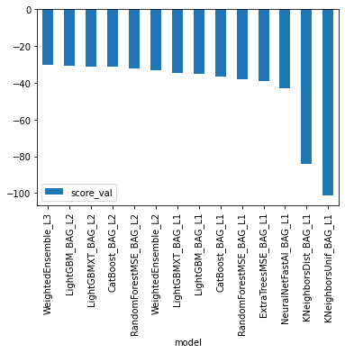

```python
predictor_new_features.leaderboard(silent=True).plot(kind="bar", x="model", y="score_val")
```

```python
# Remember to set all negative values to zero
predictions_new_features = predictor_new_features.predict(test)
pd.DataFrame(predictions_new_features).describe()
```

|  | count |
| --- | --- |
| count | 6493.000000 |
| mean | 182.732635 |
| std | 121.845314 |
| min | 5.596095 |
| 25% | 96.108009 |
| 50% | 150.936127 |
| 75% | 233.137589 |
| max | 784.169434 |

```python
print('Number of negative values: ', len(predictions_new_features[predictions_new_features<0]))
```

```
Number of negative values:  0
```

```python
# Same submitting predictions
submission_new_features = submission
submission_new_features["count"] = predictions_new_features
submission_new_features.to_csv("submission_new_features.csv", index=False)
```

```python
submission_new_features.head()
```

|  | datetime | count |
| --- | --- | --- |
| 0 | 2011-01-20 00:00:00 | 63.027222 |
| 1 | 2011-01-20 01:00:00 | 65.655380 |
| 2 | 2011-01-20 02:00:00 | 65.029442 |
| 3 | 2011-01-20 03:00:00 | 59.730362 |
| 4 | 2011-01-20 04:00:00 | 56.964897 |

```python
!kaggle competitions submit -c bike-sharing-demand -f submission_new_features.csv -m "new features"
```

```
Successfully submitted to Bike Sharing Demand
```

```python
!kaggle competitions submissions -c bike-sharing-demand | tail -n +1 | head -n 6
```

```
fileName                     date                 description           status    publicScore  privateScore
---------------------------  -------------------  --------------------  --------  -----------  ------------
submission_new_features.csv  2022-11-22 23:20:01  new features          complete  1.18505      1.18505
submission.csv               2022-11-22 21:26:54  first raw submission  complete  1.79652      1.79652
```

#### New Score of 1.18505

# Lets try dropping a highly correlated column (atemp) and also some rows where it looks like the temp sensors broke

```python
predictor_new_features_drop = TabularPredictor(
    label = 'count'
    , eval_metric = 'root_mean_squared_error'
).fit(
    train_data = train.drop(
        columns = ['casual', 'registered', 'atemp']
        , index = train[(train['atemp']>= 10) & (train['atemp'] <= 20) & (train['temp'] >= 20) & (train['temp'] <= 40)].index
    )
    ,time_limit = 600
    , presets = 'best_quality'
)
```

```
No path specified. Models will be saved in: "AutogluonModels/ag-20221126_130103/"
Presets specified: ['best_quality']
Stack configuration (auto_stack=True): num_stack_levels=1, num_bag_folds=8, num_bag_sets=20
Beginning AutoGluon training ... Time limit = 600s
AutoGluon will save models to "AutogluonModels/ag-20221126_130103/"
AutoGluon Version:  0.6.0
Python Version:     3.7.10
Operating System:   Linux
Platform Machine:   x86_64
Platform Version:   #1 SMP Thu Sep 29 01:01:23 UTC 2022
Train Data Rows:    10862
Train Data Columns: 13
Label Column: count
Preprocessing data ...
AutoGluon infers your prediction problem is: 'regression' (because dtype of label-column == int and many unique label-values observed).
	Label info (max, min, mean, stddev): (977, 1, 191.33935, 180.99407)
	If 'regression' is not the correct problem_type, please manually specify the problem_type parameter during predictor init (You may specify problem_type as one of: ['binary', 'multiclass', 'regression'])
Using Feature Generators to preprocess the data ...
Fitting AutoMLPipelineFeatureGenerator...
	Available Memory:                    2785.22 MB
	Train Data (Original)  Memory Usage: 0.45 MB (0.0% of available memory)
	Inferring data type of each feature based on column values. Set feature_metadata_in to manually specify special dtypes of the features.
	Stage 1 Generators:
		Fitting AsTypeFeatureGenerator...
			Note: Converting 3 features to boolean dtype as they only contain 2 unique values.
	Stage 2 Generators:
		Fitting FillNaFeatureGenerator...
	Stage 3 Generators:
		Fitting IdentityFeatureGenerator...
		Fitting CategoryFeatureGenerator...
			Fitting CategoryMemoryMinimizeFeatureGenerator...
		Fitting DatetimeFeatureGenerator...
	Stage 4 Generators:
		Fitting DropUniqueFeatureGenerator...
	Types of features in original data (raw dtype, special dtypes):
		('category', []) : 9 | ['season', 'holiday', 'workingday', 'weather', 'month', ...]
		('datetime', []) : 1 | ['datetime']
		('float', [])    : 2 | ['temp', 'windspeed']
		('int', [])      : 1 | ['humidity']
	Types of features in processed data (raw dtype, special dtypes):
```

[output cut: 67 more lines]

```
	-32.2916	 = Validation score   (-root_mean_squared_error)
	30.24s	 = Training   runtime
	0.61s	 = Validation runtime
Fitting model: CatBoost_BAG_L2 ... Training model for up to 73.31s of the 73.29s of remaining time.
	Fitting 8 child models (S1F1 - S1F8) | Fitting with ParallelLocalFoldFittingStrategy
	-31.1218	 = Validation score   (-root_mean_squared_error)
	71.1s	 = Training   runtime
	0.16s	 = Validation runtime
Completed 1/20 k-fold bagging repeats ...
Fitting model: WeightedEnsemble_L3 ... Training model for up to 360.0s of the -1.8s of remaining time.
	-30.295	 = Validation score   (-root_mean_squared_error)
	0.28s	 = Training   runtime
	0.0s	 = Validation runtime
AutoGluon training complete, total runtime = 602.28s ... Best model: "WeightedEnsemble_L3"
TabularPredictor saved. To load, use: predictor = TabularPredictor.load("AutogluonModels/ag-20221126_130103/")
```

```python
predictor_new_features_drop.fit_summary()
```

```
*** Summary of fit() ***
Estimated performance of each model:
                     model   score_val  pred_time_val    fit_time  pred_time_val_marginal  fit_time_marginal  stack_level  can_infer  fit_order
0      WeightedEnsemble_L3  -30.295010      15.271175  521.400980                0.000819           0.276510            3       True         14
1          LightGBM_BAG_L2  -30.716063      14.104479  419.509040                0.658323          28.870710            2       True         11
2        LightGBMXT_BAG_L2  -31.077750      14.456335  421.152014                1.010180          30.513684            2       True         10
3          CatBoost_BAG_L2  -31.121845      13.601853  461.740077                0.155698          71.101747            2       True         13
4   RandomForestMSE_BAG_L2  -32.291641      14.056560  420.873660                0.610404          30.235330            2       True         12
5      WeightedEnsemble_L2  -32.987271      12.301875  342.556008                0.000863           0.491045            2       True          9
6        LightGBMXT_BAG_L1  -34.545785       6.685436   66.197382                6.685436          66.197382            1       True          3
7          LightGBM_BAG_L1  -34.928072       4.566302   56.251320                4.566302          56.251320            1       True          4
8          CatBoost_BAG_L1  -36.707163       0.376647  206.636332                0.376647         206.636332            1       True          6
9   RandomForestMSE_BAG_L1  -38.122887       0.568680   12.957419                0.568680          12.957419            1       True          5
10    ExtraTreesMSE_BAG_L1  -38.643920       0.544568    5.974403                0.544568           5.974403            1       True          7
11  NeuralNetFastAI_BAG_L1  -44.491635       0.496880   42.574173                0.496880          42.574173            1       True          8
12   KNeighborsDist_BAG_L1  -84.096622       0.103948    0.022511                0.103948           0.022511            1       True          2
13   KNeighborsUnif_BAG_L1 -101.570834       0.103695    0.024790                0.103695           0.024790            1       True          1
Number of models trained: 14
Types of models trained:
{'StackerEnsembleModel_KNN', 'StackerEnsembleModel_XT', 'StackerEnsembleModel_RF', 'StackerEnsembleModel_NNFastAiTabular', 'WeightedEnsembleModel', 'StackerEnsembleModel_CatBoost', 'StackerEnsembleModel_LGB'}
Bagging used: True  (with 8 folds)
Multi-layer stack-ensembling used: True  (with 3 levels)
Feature Metadata (Processed):
(raw dtype, special dtypes):
('category', [])             : 6 | ['season', 'weather', 'month', 'hour', 'day', ...]
('float', [])                : 2 | ['temp', 'windspeed']
('int', [])                  : 1 | ['humidity']
('int', ['bool'])            : 3 | ['holiday', 'workingday', 'workinghours']
('int', ['datetime_as_int']) : 5 | ['datetime', 'datetime.year', 'datetime.month', 'datetime.day', 'datetime.dayofweek']
Plot summary of models saved to file: AutogluonModels/ag-20221126_130103/SummaryOfModels.html
*** End of fit() summary ***
```

[output not shown]

[output cut: 126 more lines]

```
     fit_order
 0          14
 1          11
 2          10
 3          13
 4          12
 5           9
 6           3
 7           4
 8           6
 9           5
 10          7
 11          8
 12          2
 13          1  }
```

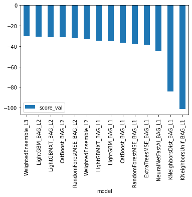

```python
predictor_new_features_drop.leaderboard(silent=True).plot(kind="bar", x="model", y="score_val")
```

```python
# Remember to set all negative values to zero
predictions_new_features_drop = predictor_new_features_drop.predict(test)
pd.DataFrame(predictions_new_features_drop).describe()
print('Number of negative values: ', len(predictions_new_features_drop[predictions_new_features_drop<0]))
```

```
Number of negative values:  0
```

```python
# Same submitting predictions
submission_new_features_drop = submission
submission_new_features_drop["count"] = predictions_new_features_drop
submission_new_features_drop.to_csv("submission_new_features_drop.csv", index=False)
```

```python
!kaggle competitions submit -c bike-sharing-demand -f submission_new_features_drop.csv -m "new features drop"
!kaggle competitions submissions -c bike-sharing-demand | tail -n +1 | head -n 6
```

```
Successfully submitted to Bike Sharing DemandfileName                          date                 description                        status    publicScore  privateScore
--------------------------------  -------------------  ---------------------------------  --------  -----------  ------------
submission_new_features_drop.csv  2022-11-26 13:28:53  new features drop                  complete  1.22509      1.22509
submission_new_features.csv       2022-11-26 13:28:40  new features drop                  complete  1.19436      1.19436
submission_new_hpo.csv            2022-11-24 19:45:46  new features with hyperparameters  complete  0.60111      0.60111
submission_new_features.csv       2022-11-22 23:20:01  new features                       complete  1.18505      1.18505
```

#### Score of 1.22509

# Now we will standardize our continuous features and drop atemp and see how this goes

```python
# Standarize feature values to have a zero mean
from sklearn.preprocessing import StandardScaler
scaler = StandardScaler()
scaler.fit(train[['temp', 'humidity', 'windspeed']])

trainScaled = train
trainScaled.loc[:, ['temp', 'humidity', 'windspeed']] = scaler.transform(trainScaled[['temp', 'humidity', 'windspeed']])

testScaled = test
testScaled.loc[:, ['temp', 'humidity', 'windspeed']] = scaler.transform(testScaled[['temp', 'humidity', 'windspeed']])
```

```python
predictor_new_features_drop_atemp_scale = TabularPredictor(
    label = 'count'
    , eval_metric = 'root_mean_squared_error'
).fit(
    train_data = trainScaled.drop(columns = ['casual', 'registered', 'atemp'])
    ,time_limit = 600
    , presets = 'best_quality'
)
```

```
No path specified. Models will be saved in: "AutogluonModels/ag-20221126_134459/"
Presets specified: ['best_quality']
Stack configuration (auto_stack=True): num_stack_levels=1, num_bag_folds=8, num_bag_sets=20
Beginning AutoGluon training ... Time limit = 600s
AutoGluon will save models to "AutogluonModels/ag-20221126_134459/"
AutoGluon Version:  0.6.0
Python Version:     3.7.10
Operating System:   Linux
Platform Machine:   x86_64
Platform Version:   #1 SMP Thu Sep 29 01:01:23 UTC 2022
Train Data Rows:    10886
Train Data Columns: 13
Label Column: count
Preprocessing data ...
AutoGluon infers your prediction problem is: 'regression' (because dtype of label-column == int and many unique label-values observed).
	Label info (max, min, mean, stddev): (977, 1, 191.57413, 181.14445)
	If 'regression' is not the correct problem_type, please manually specify the problem_type parameter during predictor init (You may specify problem_type as one of: ['binary', 'multiclass', 'regression'])
Using Feature Generators to preprocess the data ...
Fitting AutoMLPipelineFeatureGenerator...
	Available Memory:                    1657.64 MB
	Train Data (Original)  Memory Usage: 0.45 MB (0.0% of available memory)
	Inferring data type of each feature based on column values. Set feature_metadata_in to manually specify special dtypes of the features.
	Stage 1 Generators:
		Fitting AsTypeFeatureGenerator...
			Note: Converting 3 features to boolean dtype as they only contain 2 unique values.
	Stage 2 Generators:
		Fitting FillNaFeatureGenerator...
	Stage 3 Generators:
		Fitting IdentityFeatureGenerator...
		Fitting CategoryFeatureGenerator...
			Fitting CategoryMemoryMinimizeFeatureGenerator...
		Fitting DatetimeFeatureGenerator...
	Stage 4 Generators:
		Fitting DropUniqueFeatureGenerator...
	Types of features in original data (raw dtype, special dtypes):
		('category', []) : 9 | ['season', 'holiday', 'workingday', 'weather', 'month', ...]
		('datetime', []) : 1 | ['datetime']
		('float', [])    : 3 | ['temp', 'humidity', 'windspeed']
	Types of features in processed data (raw dtype, special dtypes):
		('category', [])             : 6 | ['season', 'weather', 'month', 'hour', 'day', ...]
```

[output cut: 60 more lines]

```
	Fitting 8 child models (S1F1 - S1F8) | Fitting with ParallelLocalFoldFittingStrategy
	-31.0167	 = Validation score   (-root_mean_squared_error)
	89.49s	 = Training   runtime
	0.18s	 = Validation runtime
Fitting model: ExtraTreesMSE_BAG_L2 ... Training model for up to 2.66s of the 2.64s of remaining time.
	-32.2055	 = Validation score   (-root_mean_squared_error)
	9.27s	 = Training   runtime
	0.61s	 = Validation runtime
Completed 1/20 k-fold bagging repeats ...
Fitting model: WeightedEnsemble_L3 ... Training model for up to 360.0s of the -9.8s of remaining time.
	-30.3434	 = Validation score   (-root_mean_squared_error)
	0.34s	 = Training   runtime
	0.0s	 = Validation runtime
AutoGluon training complete, total runtime = 610.36s ... Best model: "WeightedEnsemble_L3"
TabularPredictor saved. To load, use: predictor = TabularPredictor.load("AutogluonModels/ag-20221126_134459/")
```

```python
predictor_new_features_drop_atemp_scale.fit_summary()
```

```
*** Summary of fit() ***
Estimated performance of each model:
                     model   score_val  pred_time_val    fit_time  pred_time_val_marginal  fit_time_marginal  stack_level  can_infer  fit_order
0      WeightedEnsemble_L3  -30.343420      13.954294  491.733443                0.000845           0.340688            3       True         13
1          LightGBM_BAG_L2  -30.765415      12.852631  371.565227                0.410002          26.766153            2       True          9
2        LightGBMXT_BAG_L2  -31.010896      13.365349  375.140584                0.922720          30.341509            2       True          8
3          CatBoost_BAG_L2  -31.016652      12.620727  434.285093                0.178098          89.486019            2       True         11
4     ExtraTreesMSE_BAG_L2  -32.205498      13.057313  354.071443                0.614684           9.272368            2       True         12
5   RandomForestMSE_BAG_L2  -32.367642      13.056255  371.433129                0.613626          26.634054            2       True         10
6      WeightedEnsemble_L2  -32.981944      12.337792  345.319164                0.001395           0.558590            2       True          7
7        LightGBMXT_BAG_L1  -34.518073       7.353596   71.442458                7.353596          71.442458            1       True          3
8          LightGBM_BAG_L1  -35.060507       3.701737   51.997771                3.701737          51.997771            1       True          4
9          CatBoost_BAG_L1  -36.865578       0.363923  206.975820                0.363923         206.975820            1       True          6
10  RandomForestMSE_BAG_L1  -37.836408       0.809207   14.306059                0.809207          14.306059            1       True          5
11   KNeighborsDist_BAG_L1  -84.125061       0.107935    0.038465                0.107935           0.038465            1       True          2
12   KNeighborsUnif_BAG_L1 -101.546199       0.106231    0.038501                0.106231           0.038501            1       True          1
Number of models trained: 13
Types of models trained:
{'StackerEnsembleModel_KNN', 'StackerEnsembleModel_XT', 'StackerEnsembleModel_RF', 'WeightedEnsembleModel', 'StackerEnsembleModel_CatBoost', 'StackerEnsembleModel_LGB'}
Bagging used: True  (with 8 folds)
Multi-layer stack-ensembling used: True  (with 3 levels)
Feature Metadata (Processed):
(raw dtype, special dtypes):
('category', [])             : 6 | ['season', 'weather', 'month', 'hour', 'day', ...]
('float', [])                : 3 | ['temp', 'humidity', 'windspeed']
('int', ['bool'])            : 3 | ['holiday', 'workingday', 'workinghours']
('int', ['datetime_as_int']) : 5 | ['datetime', 'datetime.year', 'datetime.month', 'datetime.day', 'datetime.dayofweek']
Plot summary of models saved to file: AutogluonModels/ag-20221126_134459/SummaryOfModels.html
*** End of fit() summary ***
```

[output not shown]

[output cut: 114 more lines]

```

     fit_order
 0          13
 1           9
 2           8
 3          11
 4          12
 5          10
 6           7
 7           3
 8           4
 9           6
 10          5
 11          2
 12          1  }
```

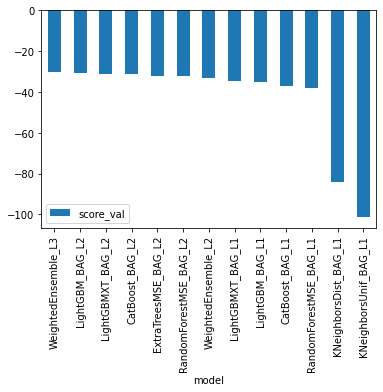

```python
predictor_new_features_drop_atemp_scale.leaderboard(silent=True).plot(kind="bar", x="model", y="score_val")
```

```python
# Remember to set all negative values to zero
predictions_new_features_drop_atemp_scale = predictor_new_features_drop_atemp_scale.predict(testScaled)
pd.DataFrame(predictions_new_features_drop_atemp_scale).describe()
print('Number of negative values: ', len(predictions_new_features_drop_atemp_scale[predictions_new_features_drop_atemp_scale<0]))
```

```
Number of negative values:  0
```

```python
# Same submitting predictions
submission_new_features_drop_atemp_scale = submission
submission_new_features_drop_atemp_scale["count"] = predictions_new_features_drop_atemp_scale
submission_new_features_drop_atemp_scale.to_csv("submission_new_features_drop_atemp_scale.csv", index=False)
```

```python
!kaggle competitions submit -c bike-sharing-demand -f submission_new_features_drop_atemp_scale.csv -m "new features drop atemp scale"
!kaggle competitions submissions -c bike-sharing-demand | tail -n +1 | head -n 6
```

```
Successfully submitted to Bike Sharing DemandfileName                                      date                 description                        status    publicScore  privateScore
--------------------------------------------  -------------------  ---------------------------------  --------  -----------  ------------
submission_new_features_drop_atemp_scale.csv  2022-11-26 14:06:49  new features drop atemp scale      complete  1.20487      1.20487
submission_new_features_drop.csv              2022-11-26 13:28:53  new features drop                  complete  1.22509      1.22509
submission_new_features.csv                   2022-11-26 13:28:40  new features drop                  complete  1.19436      1.19436
submission_new_hpo.csv                        2022-11-24 19:45:46  new features with hyperparameters  complete  0.60111      0.60111
```

#### New Score of 1.2048

## Step 6: Hyper parameter optimization

- There are many options for hyper parameter optimization.
- Options are to change the AutoGluon higher level parameters or the individual model hyperparameters.
- The hyperparameters of the models themselves that are in AutoGluon. Those need the `hyperparameter` and `hyperparameter_tune_kwargs` arguments.

```python
# hyperparam options taken from https://auto.gluon.ai/stable/tutorials/tabular_prediction/tabular-indepth.html
import autogluon.core as ag

time_limit = 2*60  # train various models for ~2 min
num_trials = 5  # try at most 5 different hyperparameter configurations for each type of model
search_strategy = 'auto'  # to tune hyperparameters using random search routine with a local scheduler

hyperparameter_tune_kwargs = {  # HPO is not performed unless hyperparameter_tune_kwargs is specified
    'num_trials': num_trials,
    'scheduler' : 'local',
    'searcher': search_strategy,
}

gbm_options = {
    'num_boost_round': 100,
    'num_leaves': ag.space.Int(lower=26, upper=66, default=36)
}

hyperparameters = {
    'GBM': gbm_options
}

predictor_new_hpo = TabularPredictor(
    label = 'count'
    , eval_metric = 'root_mean_squared_error'
).fit(
    train_data = train.drop(columns = ['casual', 'registered'])
    , time_limit = 600
    , presets = 'best_quality'
    , hyperparameters = hyperparameters
    , hyperparameter_tune_kwargs = hyperparameter_tune_kwargs
)
```

[output not shown]

[output cut: 107 more lines]

```
Fitted model: LightGBM_BAG_L2/T4 ...
	-102.9459	 = Validation score   (-root_mean_squared_error)
	23.49s	 = Training   runtime
	0.0s	 = Validation runtime
Fitted model: LightGBM_BAG_L2/T5 ...
	-37.684	 = Validation score   (-root_mean_squared_error)
	23.82s	 = Training   runtime
	0.0s	 = Validation runtime
Completed 1/20 k-fold bagging repeats ...
Fitting model: WeightedEnsemble_L3 ... Training model for up to 360.0s of the 129.04s of remaining time.
	-36.9907	 = Validation score   (-root_mean_squared_error)
	0.45s	 = Training   runtime
	0.0s	 = Validation runtime
AutoGluon training complete, total runtime = 471.6s ... Best model: "WeightedEnsemble_L3"
TabularPredictor saved. To load, use: predictor = TabularPredictor.load("AutogluonModels/ag-20221124_185003/")
```

```python
predictor_new_hpo.fit_summary()
```

```
*** Summary of fit() ***
Estimated performance of each model:
                  model   score_val  pred_time_val    fit_time  pred_time_val_marginal  fit_time_marginal  stack_level  can_infer  fit_order
0   WeightedEnsemble_L3  -36.990667       2.020851  355.387377                0.001284           0.445714            3       True         12
1    LightGBM_BAG_L2/T3  -37.167381       2.019476  331.619398                0.000081          24.478052            2       True          9
2    LightGBM_BAG_L2/T2  -37.255563       2.019486  330.463611                0.000092          23.322265            2       True          8
3    LightGBM_BAG_L2/T1  -37.303656       2.019512  331.046425                0.000118          23.905079            2       True          7
4    LightGBM_BAG_L2/T5  -37.684014       2.019473  330.960025                0.000078          23.818679            2       True         11
5   WeightedEnsemble_L2  -38.561765       0.864591  123.963078                0.001143           0.392415            2       True          6
6    LightGBM_BAG_L1/T2  -38.614196       0.391201   59.958010                0.391201          59.958010            1       True          2
7    LightGBM_BAG_L1/T3  -39.854993       0.472247   63.612653                0.472247          63.612653            1       True          3
8    LightGBM_BAG_L1/T1  -40.582120       0.412529   61.594990                0.412529          61.594990            1       True          1
9    LightGBM_BAG_L1/T5  -44.959846       0.416522   61.669129                0.416522          61.669129            1       True          5
10   LightGBM_BAG_L2/T4 -102.945929       2.019513  330.626795                0.000118          23.485449            2       True         10
11   LightGBM_BAG_L1/T4 -117.050503       0.326896   60.306563                0.326896          60.306563            1       True          4
Number of models trained: 12
Types of models trained:
{'WeightedEnsembleModel', 'StackerEnsembleModel_LGB'}
Bagging used: True  (with 8 folds)
Multi-layer stack-ensembling used: True  (with 3 levels)
Feature Metadata (Processed):
(raw dtype, special dtypes):
('category', [])             : 6 | ['season', 'weather', 'month', 'hour', 'day', ...]
('float', [])                : 3 | ['temp', 'atemp', 'windspeed']
('int', [])                  : 1 | ['humidity']
('int', ['bool'])            : 3 | ['holiday', 'workingday', 'workinghours']
('int', ['datetime_as_int']) : 5 | ['datetime', 'datetime.year', 'datetime.month', 'datetime.day', 'datetime.dayofweek']
Plot summary of models saved to file: AutogluonModels/ag-20221124_185003/SummaryOfModels.html
*** End of fit() summary ***
```

[output not shown]

[output cut: 97 more lines]

```
 11                0.326896          60.306563            1       True

     fit_order
 0          12
 1           9
 2           8
 3           7
 4          11
 5           6
 6           2
 7           3
 8           1
 9           5
 10         10
 11          4  }
```

```python
# Remember to set all negative values to zero
predictions_new_features_hpo = predictor_new_hpo.predict(test)
pd.DataFrame(predictions_new_features_hpo).describe()
```

|  | count |
| --- | --- |
| count | 6493.000000 |
| mean | 197.098450 |
| std | 174.159164 |
| min | 4.647927 |
| 25% | 57.834076 |
| 50% | 153.387970 |
| 75% | 290.686188 |
| max | 868.493042 |

```python
print('Number of negative values: ', len(predictions_new_features_hpo[predictions_new_features_hpo < 0]))
```

```
Number of negative values:  0
```

```python
# Same submitting predictions
submission_new_hpo = submission
submission_new_hpo["count"] = predictions_new_features_hpo
submission_new_hpo.to_csv("submission_new_hpo.csv", index=False)
```

```python
!kaggle competitions submit -c bike-sharing-demand -f submission_new_hpo.csv -m "new features with hyperparameters"
```

```
Successfully submitted to Bike Sharing Demand
```

```python
!kaggle competitions submissions -c bike-sharing-demand | tail -n +1 | head -n 6
```

```
fileName                     date                 description                        status    publicScore  privateScore
---------------------------  -------------------  ---------------------------------  --------  -----------  ------------
submission_new_hpo.csv       2022-11-24 19:45:46  new features with hyperparameters  complete  0.60111      0.60111
submission_new_features.csv  2022-11-22 23:20:01  new features                       complete  1.18505      1.18505
submission.csv               2022-11-22 21:26:54  first raw submission               complete  1.79652      1.79652
```

#### New Score of 0.60111

## Lets try with hyperparameters for neural networks

```python
# hyperparam options taken from https://auto.gluon.ai/stable/tutorials/tabular_prediction/tabular-indepth.html
import autogluon.core as ag

time_limit = 2*60  # train various models for ~2 min
num_trials = 5  # try at most 5 different hyperparameter configurations for each type of model
search_strategy = 'auto'  # to tune hyperparameters using random search routine with a local scheduler

hyperparameter_tune_kwargs = {  # HPO is not performed unless hyperparameter_tune_kwargs is specified
    'num_trials': num_trials,
    'scheduler' : 'local',
    'searcher': search_strategy,
}

gbm_options = {
    'num_boost_round': 100,
    'num_leaves': ag.space.Int(lower=26, upper=66, default=36)
}

nn_options = {  # specifies non-default hyperparameter values for neural network model
    'num_epochs': 10,  # number of training epochs (controls training time of NN models)
    'learning_rate': ag.space.Real(1e-4, 1e-2, default=5e-4, log=True),  # learning rate used in training (real-valued hyperparameter searched on log-scale)
    'activation': ag.space.Categorical('relu', 'softrelu', 'tanh'),  # activation function used in NN (categorical hyperparameter, default = first entry)
    'dropout_prob': ag.space.Real(0.0, 0.5, default=0.1),  # dropout probability (real-valued hyperparameter)
}

hyperparameters = {
    'GBM': gbm_options
    ,'NN_TORCH': nn_options
}

predictor_new_hpo_incl_nn = TabularPredictor(
    label = 'count'
    , eval_metric = 'root_mean_squared_error'
).fit(
    train_data = train.drop(columns = ['casual', 'registered'])
    , time_limit = 600
    , presets = 'best_quality'
    , hyperparameters = hyperparameters
    , hyperparameter_tune_kwargs = hyperparameter_tune_kwargs
)
```

```
Fitted model: NeuralNetTorch_BAG_L2/26b6b810 ...
	-38.6812	 = Validation score   (-root_mean_squared_error)
	61.79s	 = Training   runtime
	0.0s	 = Validation runtime
Fitted model: NeuralNetTorch_BAG_L2/27bc1caa ...
	-38.6963	 = Validation score   (-root_mean_squared_error)
	64.9s	 = Training   runtime
	0.0s	 = Validation runtime
Completed 1/20 k-fold bagging repeats ...
Fitting model: WeightedEnsemble_L3 ... Training model for up to 360.0s of the 33.42s of remaining time.
	-36.5123	 = Validation score   (-root_mean_squared_error)
	0.47s	 = Training   runtime
	0.0s	 = Validation runtime
AutoGluon training complete, total runtime = 567.27s ... Best model: "WeightedEnsemble_L3"
TabularPredictor saved. To load, use: predictor = TabularPredictor.load("AutogluonModels/ag-20221127_165420/")
```

```python
predictor_new_hpo_incl_nn.fit_summary()
```

```
*** Summary of fit() ***
Estimated performance of each model:
                             model   score_val  pred_time_val    fit_time  pred_time_val_marginal  fit_time_marginal  stack_level  can_infer  fit_order
0              WeightedEnsemble_L3  -36.512286       0.002539  476.184825                0.001276           0.471016            3       True         16
1               LightGBM_BAG_L2/T2  -36.861913       0.000852  324.729126                0.000116          26.054755            2       True         10
2               LightGBM_BAG_L2/T3  -37.040960       0.000823  322.968426                0.000087          24.294055            2       True         11
3               LightGBM_BAG_L2/T1  -37.051050       0.000863  322.281549                0.000126          23.607178            2       True          9
4               LightGBM_BAG_L2/T5  -37.523157       0.000860  322.727105                0.000123          24.052734            2       True         13
5              WeightedEnsemble_L2  -38.453669       0.001473  108.490837                0.001138           1.086947            2       True          8
6   NeuralNetTorch_BAG_L2/26b6b810  -38.681210       0.000865  360.466658                0.000129          61.792287            2       True         14
7   NeuralNetTorch_BAG_L2/27bc1caa  -38.696329       0.000932  363.572712                0.000195          64.898341            2       True         15
8               LightGBM_BAG_L1/T2  -39.238850       0.000121   23.767399                0.000121          23.767399            1       True          2
9               LightGBM_BAG_L1/T3  -40.448089       0.000092   23.715506                0.000092          23.715506            1       True          3
10              LightGBM_BAG_L1/T1  -41.090999       0.000082   34.278261                0.000082          34.278261            1       True          1
11  NeuralNetTorch_BAG_L1/70a61336  -43.985919       0.000123   59.920986                0.000123          59.920986            1       True          6
12              LightGBM_BAG_L1/T5  -45.208515       0.000120   22.990126                0.000120          22.990126            1       True          5
13  NeuralNetTorch_BAG_L1/71955c66  -60.570106       0.000116  110.144538                0.000116         110.144538            1       True          7
14              LightGBM_BAG_L2/T4 -102.964939       0.000817  323.032746                0.000081          24.358375            2       True         12
15              LightGBM_BAG_L1/T4 -117.068263       0.000082   23.857555                0.000082          23.857555            1       True          4
Number of models trained: 16
Types of models trained:
{'WeightedEnsembleModel', 'StackerEnsembleModel_LGB', 'StackerEnsembleModel_TabularNeuralNetTorch'}
Bagging used: True  (with 8 folds)
Multi-layer stack-ensembling used: True  (with 3 levels)
Feature Metadata (Processed):
(raw dtype, special dtypes):
('category', [])             : 6 | ['season', 'weather', 'month', 'hour', 'day', ...]
('float', [])                : 3 | ['temp', 'atemp', 'windspeed']
('int', [])                  : 1 | ['humidity']
('int', ['bool'])            : 3 | ['holiday', 'workingday', 'workinghours']
('int', ['datetime_as_int']) : 5 | ['datetime', 'datetime.year', 'datetime.month', 'datetime.day', 'datetime.dayofweek']
Plot summary of models saved to file: AutogluonModels/ag-20221127_165420/SummaryOfModels.html
*** End of fit() summary ***
```

[output not shown]

[output cut: 145 more lines]

```
 1          10
 2          11
 3           9
 4          13
 5           8
 6          14
 7          15
 8           2
 9           3
 10          1
 11          6
 12          5
 13          7
 14         12
 15          4  }
```

```python
# Remember to set all negative values to zero
predictions_new_hpo_incl_nn = predictor_new_hpo_incl_nn.predict(test)
print(pd.DataFrame(predictions_new_hpo_incl_nn).describe())

print('Number of negative values: ', len(predictions_new_hpo_incl_nn[predictions_new_hpo_incl_nn < 0]))

# Same submitting predictions
submission_new_features_nn_hpo = submission
submission_new_features_nn_hpo["count"] = predictions_new_hpo_incl_nn
submission_new_features_nn_hpo.to_csv("submission_new_features_nn_hpo.csv", index=False)

!kaggle competitions submit -c bike-sharing-demand -f submission_new_features_nn_hpo.csv -m "new features with hyperparameters incl nn"
!kaggle competitions submissions -c bike-sharing-demand | tail -n +1 | head -n 6
```

```
             count
count  6493.000000
mean    201.434158
std     167.656952
min       4.444938
25%      71.390762
50%     159.365814
75%     280.086456
max     880.250488
Number of negative values:  0
Successfully submitted to Bike Sharing DemandfileName                                      date                 description                                status    publicScore  privateScore
--------------------------------------------  -------------------  -----------------------------------------  --------  -----------  ------------
submission_new_features_nn_hpo.csv            2022-11-27 17:03:59  new features with hyperparameters incl nn  complete  0.75512      0.75512
submission_new_features_drop_atemp_scale.csv  2022-11-26 14:06:49  new features drop atemp scale              complete  1.20487      1.20487
submission_new_features_drop.csv              2022-11-26 13:28:53  new features drop                          complete  1.22509      1.22509
submission_new_features.csv                   2022-11-26 13:28:40  new features drop                          complete  1.19436      1.19436
```

## Lets try with those hyperparameters and also incorporating bagging and stack-ensembling

This might not lead to any changes as when presets = 'best_quality' (as we've been using) the auto_stack argument, which finds bag/stack values for you, gets set to true.

```python
# hyperparam options taken from https://auto.gluon.ai/stable/tutorials/tabular_prediction/tabular-indepth.html
import autogluon.core as ag

time_limit = 2*60  # train various models for ~2 min
num_trials = 5  # try at most 5 different hyperparameter configurations for each type of model
search_strategy = 'auto'  # to tune hyperparameters using random search routine with a local scheduler

hyperparameter_tune_kwargs = {  # HPO is not performed unless hyperparameter_tune_kwargs is specified
    'num_trials': num_trials,
    'scheduler' : 'local',
    'searcher': search_strategy,
}

gbm_options = {
    'num_boost_round': 100,
    'num_leaves': ag.space.Int(lower=26, upper=66, default=36)
}

nn_options = {  # specifies non-default hyperparameter values for neural network model
    'num_epochs': 10,  # number of training epochs (controls training time of NN models)
    'learning_rate': ag.space.Real(1e-4, 1e-2, default=5e-4, log=True),  # learning rate used in training (real-valued hyperparameter searched on log-scale)
    'activation': ag.space.Categorical('relu', 'softrelu', 'tanh'),  # activation function used in NN (categorical hyperparameter, default = first entry)
    'dropout_prob': ag.space.Real(0.0, 0.5, default=0.1),  # dropout probability (real-valued hyperparameter)
}

hyperparameters = {
    'GBM': gbm_options
    ,'NN_TORCH': nn_options
}

predictor_new_hpo_stack_bag = TabularPredictor(
    label = 'count'
    , eval_metric = 'root_mean_squared_error'
).fit(
    train_data = train.drop(columns = ['casual', 'registered'])
    , num_bag_folds=5
    , num_bag_sets=1
    , num_stack_levels=1
    , time_limit = 600
    , presets = 'best_quality'
    , hyperparameters = hyperparameters
    , hyperparameter_tune_kwargs = hyperparameter_tune_kwargs
)
```

```
Fitted model: NeuralNetTorch_BAG_L2/45f45f10 ...
	-39.0867	 = Validation score   (-root_mean_squared_error)
	38.65s	 = Training   runtime
	0.0s	 = Validation runtime
Fitted model: NeuralNetTorch_BAG_L2/46d3ed4c ...
	-39.6279	 = Validation score   (-root_mean_squared_error)
	90.35s	 = Training   runtime
	0.0s	 = Validation runtime
Fitting model: WeightedEnsemble_L3 ... Training model for up to 360.0s of the 105.68s of remaining time.
	-36.6122	 = Validation score   (-root_mean_squared_error)
	0.47s	 = Training   runtime
	0.0s	 = Validation runtime
AutoGluon training complete, total runtime = 494.99s ... Best model: "WeightedEnsemble_L3"
TabularPredictor saved. To load, use: predictor = TabularPredictor.load("AutogluonModels/ag-20221127_170401/")
```

```python
predictor_new_hpo_stack_bag.fit_summary()
```

```
*** Summary of fit() ***
Estimated performance of each model:
                             model   score_val  pred_time_val    fit_time  pred_time_val_marginal  fit_time_marginal  stack_level  can_infer  fit_order
0              WeightedEnsemble_L3  -36.612163       0.003064  406.562546                0.001297           0.466815            3       True         18
1               LightGBM_BAG_L2/T2  -36.939109       0.001405  260.798200                0.000122          15.124451            2       True         12
2               LightGBM_BAG_L2/T1  -37.165399       0.001364  261.144889                0.000081          15.471141            2       True         11
3               LightGBM_BAG_L2/T3  -37.177559       0.001408  261.966972                0.000125          16.293223            2       True         13
4               LightGBM_BAG_L2/T5  -37.681013       0.001399  261.321228                0.000116          15.647479            2       True         15
5              WeightedEnsemble_L2  -38.507022       0.002302  109.597952                0.001584           0.937896            2       True         10
6   NeuralNetTorch_BAG_L2/45f45f10  -39.086734       0.001400  284.327829                0.000117          38.654080            2       True         16
7               LightGBM_BAG_L1/T2  -39.214134       0.000079   14.873495                0.000079          14.873495            1       True          2
8   NeuralNetTorch_BAG_L2/46d3ed4c  -39.627939       0.001403  336.023976                0.000120          90.350228            2       True         17
9               LightGBM_BAG_L1/T3  -41.318070       0.000080   15.559864                0.000080          15.559864            1       True          3
10              LightGBM_BAG_L1/T1  -41.717974       0.000119   15.013854                0.000119          15.013854            1       True          1
11  NeuralNetTorch_BAG_L1/ad591138  -45.013535       0.000450   40.031094                0.000450          40.031094            1       True          6
12  NeuralNetTorch_BAG_L1/c79fc44c  -45.908480       0.000108   38.195603                0.000108          38.195603            1       True          8
13              LightGBM_BAG_L1/T5  -46.602146       0.000083   15.213023                0.000083          15.213023            1       True          5
14  NeuralNetTorch_BAG_L1/ae3b7334  -92.666662       0.000078   37.308780                0.000078          37.308780            1       True          7
15  NeuralNetTorch_BAG_L1/dde3fc96  -93.622350       0.000197   51.178372                0.000197          51.178372            1       True          9
16              LightGBM_BAG_L2/T4 -103.043889       0.001405  260.963211                0.000122          15.289463            2       True         14
17              LightGBM_BAG_L1/T4 -117.449702       0.000087   18.299663                0.000087          18.299663            1       True          4
Number of models trained: 18
Types of models trained:
{'WeightedEnsembleModel', 'StackerEnsembleModel_LGB', 'StackerEnsembleModel_TabularNeuralNetTorch'}
Bagging used: True  (with 5 folds)
Multi-layer stack-ensembling used: True  (with 3 levels)
Feature Metadata (Processed):
(raw dtype, special dtypes):
('category', [])             : 6 | ['season', 'weather', 'month', 'hour', 'day', ...]
('float', [])                : 3 | ['temp', 'atemp', 'windspeed']
('int', [])                  : 1 | ['humidity']
('int', ['bool'])            : 3 | ['holiday', 'workingday', 'workinghours']
('int', ['datetime_as_int']) : 5 | ['datetime', 'datetime.year', 'datetime.month', 'datetime.day', 'datetime.dayofweek']
Plot summary of models saved to file: AutogluonModels/ag-20221127_170401/SummaryOfModels.html
*** End of fit() summary ***
```

[output not shown]

[output cut: 169 more lines]

```
 3          13
 4          15
 5          10
 6          16
 7           2
 8          17
 9           3
 10          1
 11          6
 12          8
 13          5
 14          7
 15          9
 16         14
 17          4  }
```

```python
# Remember to set all negative values to zero
predictions_new_hpo_stack_bag = predictor_new_hpo_stack_bag.predict(test)
print(pd.DataFrame(predictions_new_hpo_stack_bag).describe())

print('Number of negative values: ', len(predictions_new_hpo_stack_bag[predictions_new_hpo_stack_bag < 0]))

# Same submitting predictions
submission_new_features_hpo_stack_back = submission
submission_new_features_hpo_stack_back["count"] = predictions_new_hpo_stack_bag
submission_new_features_hpo_stack_back.to_csv("submission_new_features_hpo_stack_back.csv", index=False)

!kaggle competitions submit -c bike-sharing-demand -f submission_new_features_hpo_stack_back.csv -m "new features with hyperparameters stack bag"
!kaggle competitions submissions -c bike-sharing-demand | tail -n +1 | head -n 6
```

```
             count
count  6493.000000
mean    202.677994
std     168.546509
min       4.531601
25%      70.316849
50%     162.548386
75%     284.587769
max     885.053467
Number of negative values:  0
Successfully submitted to Bike Sharing DemandfileName                                      date                 description                                  status    publicScore  privateScore
--------------------------------------------  -------------------  -------------------------------------------  --------  -----------  ------------
submission_new_features_hpo_stack_back.csv    2022-11-27 17:12:25  new features with hyperparameters stack bag  complete  0.71526      0.71526
submission_new_features_nn_hpo.csv            2022-11-27 17:03:59  new features with hyperparameters incl nn    complete  0.75512      0.75512
submission_new_features_drop_atemp_scale.csv  2022-11-26 14:06:49  new features drop atemp scale                complete  1.20487      1.20487
submission_new_features_drop.csv              2022-11-26 13:28:53  new features drop                            complete  1.22509      1.22509
```

## Score is: 0.71526

# Lets try playing with a single hyperparameter repeatedly here - we'll alter the range in gbm_options

```python
# hyperparam options taken from https://auto.gluon.ai/stable/tutorials/tabular_prediction/tabular-indepth.html
import autogluon.core as ag

time_limit = 2*60  # train various models for ~2 min
num_trials = 5  # try at most 5 different hyperparameter configurations for each type of model
search_strategy = 'auto'  # to tune hyperparameters using random search routine with a local scheduler

hyperparameter_tune_kwargs = {  # HPO is not performed unless hyperparameter_tune_kwargs is specified
    'num_trials': num_trials,
    'scheduler' : 'local',
    'searcher': search_strategy,
}

gbm_options = {
    'num_boost_round': 100,
    'num_leaves': ag.space.Int(lower=1, upper=26, default=13)
}

hyperparameters = {
    'GBM': gbm_options
}

predictor_new_hpo_1 = TabularPredictor(
    label = 'count'
    , eval_metric = 'root_mean_squared_error'
).fit(
    train_data = train.drop(columns = ['casual', 'registered'])
    , time_limit = 600
    , presets = 'best_quality'
    , hyperparameters = hyperparameters
    , hyperparameter_tune_kwargs = hyperparameter_tune_kwargs
)
```

[output not shown]

[output cut: 107 more lines]

```
Fitted model: LightGBM_BAG_L2/T4 ...
	-128.982	 = Validation score   (-root_mean_squared_error)
	22.1s	 = Training   runtime
	0.0s	 = Validation runtime
Fitted model: LightGBM_BAG_L2/T5 ...
	-42.7642	 = Validation score   (-root_mean_squared_error)
	23.17s	 = Training   runtime
	0.0s	 = Validation runtime
Completed 1/20 k-fold bagging repeats ...
Fitting model: WeightedEnsemble_L3 ... Training model for up to 360.0s of the 145.37s of remaining time.
	-41.8606	 = Validation score   (-root_mean_squared_error)
	0.35s	 = Training   runtime
	0.0s	 = Validation runtime
AutoGluon training complete, total runtime = 455.17s ... Best model: "WeightedEnsemble_L3"
TabularPredictor saved. To load, use: predictor = TabularPredictor.load("AutogluonModels/ag-20221127_174825/")
```

```python
predictor_new_hpo_1.fit_summary()

# Remember to set all negative values to zero
predictions_new_hpo_1 = predictor_new_hpo_1.predict(test)
print(pd.DataFrame(predictions_new_hpo_1).describe())

print('Number of negative values: ', len(predictions_new_hpo_1[predictions_new_hpo_1 < 0]))
predictions_new_hpo_1[predictions_new_hpo_1 < 0] = 0

# Same submitting predictions
submission_new_features_hpo_1 = submission
submission_new_features_hpo_1["count"] = predictions_new_hpo_1
submission_new_features_hpo_1.to_csv("submission_new_features_hpo_1.csv", index=False)

!kaggle competitions submit -c bike-sharing-demand -f submission_new_features_hpo_1.csv -m "new features with hyperparameters 01"
!kaggle competitions submissions -c bike-sharing-demand | tail -n +1 | head -n 6
```

```
*** Summary of fit() ***
Estimated performance of each model:
                  model   score_val  pred_time_val    fit_time  pred_time_val_marginal  fit_time_marginal  stack_level  can_infer  fit_order
0    LightGBM_BAG_L2/T1  -41.860643       1.431359  320.362607                0.000091          22.954984            2       True          7
1   WeightedEnsemble_L3  -41.860643       1.432232  320.709778                0.000872           0.347172            3       True         12
2    LightGBM_BAG_L2/T5  -42.764233       1.431397  320.578978                0.000128          23.171355            2       True         11
3    LightGBM_BAG_L2/T2  -44.492607       1.431362  319.602397                0.000093          22.194774            2       True          8
4    LightGBM_BAG_L2/T3  -44.662545       1.431411  320.388650                0.000142          22.981027            2       True          9
5    LightGBM_BAG_L1/T1  -46.481988       0.348398   59.511148                0.348398          59.511148            1       True          1
6   WeightedEnsemble_L2  -46.481988       0.349216   59.855052                0.000818           0.343904            2       True          6
7    LightGBM_BAG_L1/T5  -49.879956       0.333046   61.459579                0.333046          61.459579            1       True          5
8    LightGBM_BAG_L1/T3  -63.334204       0.282641   59.203209                0.282641          59.203209            1       True          3
9    LightGBM_BAG_L1/T2  -69.622608       0.240720   59.488636                0.240720          59.488636            1       True          2
10   LightGBM_BAG_L2/T4 -128.981981       1.431391  319.512316                0.000123          22.104693            2       True         10
11   LightGBM_BAG_L1/T4 -154.506249       0.226463   57.745050                0.226463          57.745050            1       True          4
Number of models trained: 12
Types of models trained:
{'WeightedEnsembleModel', 'StackerEnsembleModel_LGB'}
Bagging used: True  (with 8 folds)
Multi-layer stack-ensembling used: True  (with 3 levels)
Feature Metadata (Processed):
(raw dtype, special dtypes):
('category', [])             : 6 | ['season', 'weather', 'month', 'hour', 'day', ...]
('float', [])                : 3 | ['temp', 'atemp', 'windspeed']
('int', [])                  : 1 | ['humidity']
('int', ['bool'])            : 3 | ['holiday', 'workingday', 'workinghours']
('int', ['datetime_as_int']) : 5 | ['datetime', 'datetime.year', 'datetime.month', 'datetime.day', 'datetime.dayofweek']
Plot summary of models saved to file: AutogluonModels/ag-20221127_174825/SummaryOfModels.html
*** End of fit() summary ***
             count
count  6493.000000
mean    202.807556
std     169.320053
min       5.751080
25%      71.047241
50%     158.172394
75%     290.575134
max     856.727356
Number of negative values:  0
Successfully submitted to Bike Sharing DemandfileName                                      date                 description                                  status    publicScore  privateScore
--------------------------------------------  -------------------  -------------------------------------------  --------  -----------  ------------
submission_new_features_hpo_1.csv             2022-11-27 17:56:07  new features with hyperparameters 01         complete  0.74947      0.74947
submission_new_features_hpo_stack_back.csv    2022-11-27 17:12:25  new features with hyperparameters stack bag  complete  0.71526      0.71526
submission_new_features_nn_hpo.csv            2022-11-27 17:03:59  new features with hyperparameters incl nn    complete  0.75512      0.75512
submission_new_features_drop_atemp_scale.csv  2022-11-26 14:06:49  new features drop atemp scale                complete  1.20487      1.20487
```

```python
# hyperparam options taken from https://auto.gluon.ai/stable/tutorials/tabular_prediction/tabular-indepth.html
import autogluon.core as ag

time_limit = 2*60  # train various models for ~2 min
num_trials = 5  # try at most 5 different hyperparameter configurations for each type of model
search_strategy = 'auto'  # to tune hyperparameters using random search routine with a local scheduler

hyperparameter_tune_kwargs = {  # HPO is not performed unless hyperparameter_tune_kwargs is specified
    'num_trials': num_trials,
    'scheduler' : 'local',
    'searcher': search_strategy,
}

gbm_options = {
    'num_boost_round': 100,
    'num_leaves': ag.space.Int(lower=66, upper=100, default=75)
}

hyperparameters = {
    'GBM': gbm_options
}

predictor_new_hpo_2 = TabularPredictor(
    label = 'count'
    , eval_metric = 'root_mean_squared_error'
).fit(
    train_data = train.drop(columns = ['casual', 'registered'])
    , time_limit = 600
    , presets = 'best_quality'
    , hyperparameters = hyperparameters
    , hyperparameter_tune_kwargs = hyperparameter_tune_kwargs
)
```

[output not shown]

[output cut: 107 more lines]

```
	-35.9272	 = Validation score   (-root_mean_squared_error)
	43.79s	 = Training   runtime
	0.13s	 = Validation runtime
Fitting model: LightGBM_BAG_L2/T5 ... Training model for up to 134.76s of the 134.75s of remaining time.
	Fitting 8 child models (S2F1 - S2F8) | Fitting with ParallelLocalFoldFittingStrategy
	-36.1625	 = Validation score   (-root_mean_squared_error)
	45.4s	 = Training   runtime
	0.19s	 = Validation runtime
Completed 2/20 k-fold bagging repeats ...
Fitting model: WeightedEnsemble_L3 ... Training model for up to 360.0s of the 109.64s of remaining time.
	-35.7203	 = Validation score   (-root_mean_squared_error)
	0.36s	 = Training   runtime
	0.0s	 = Validation runtime
AutoGluon training complete, total runtime = 490.91s ... Best model: "WeightedEnsemble_L2"
TabularPredictor saved. To load, use: predictor = TabularPredictor.load("AutogluonModels/ag-20221127_175609/")
```

```python
predictor_new_hpo_2.fit_summary()

# Remember to set all negative values to zero
predictions_new_hpo_2 = predictor_new_hpo_2.predict(test)
print(pd.DataFrame(predictions_new_hpo_2).describe())

print('Number of negative values: ', len(predictions_new_hpo_2[predictions_new_hpo_2 < 0]))
predictions_new_hpo_2[predictions_new_hpo_2 < 0] = 0

# Same submitting predictions
submission_new_features_hpo_2 = submission
submission_new_features_hpo_2["count"] = predictions_new_hpo_2
submission_new_features_hpo_2.to_csv("submission_new_features_hpo_2.csv", index=False)

!kaggle competitions submit -c bike-sharing-demand -f submission_new_features_hpo_2.csv -m "new features with hyperparameters 02"
!kaggle competitions submissions -c bike-sharing-demand | tail -n +1 | head -n 6
```

```
*** Summary of fit() ***
Estimated performance of each model:
                  model  score_val  pred_time_val    fit_time  pred_time_val_marginal  fit_time_marginal  stack_level  can_infer  fit_order
0   WeightedEnsemble_L2 -35.371523       0.478947   87.948241                0.000806           0.342683            2       True          6
1   WeightedEnsemble_L3 -35.720319       1.812413  401.156933                0.000924           0.358671            3       True         12
2    LightGBM_BAG_L1/T4 -35.775773       0.260816   43.400400                0.260816          43.400400            1       True          4
3    LightGBM_BAG_L2/T4 -35.927244       1.317540  266.728387                0.127503          43.785536            2       True         10
4    LightGBM_BAG_L2/T3 -35.935452       1.377552  267.941426                0.187515          44.998575            2       True          9
5    LightGBM_BAG_L2/T2 -35.942153       1.336552  267.768822                0.146515          44.825971            2       True          8
6    LightGBM_BAG_L2/T1 -35.977861       1.349957  267.188181                0.159919          44.245330            2       True          7
7    LightGBM_BAG_L2/T5 -36.162532       1.377806  268.346229                0.187769          45.403378            2       True         11
8    LightGBM_BAG_L1/T2 -36.785989       0.217325   44.205158                0.217325          44.205158            1       True          2
9    LightGBM_BAG_L1/T3 -39.424700       0.251924   44.862243                0.251924          44.862243            1       True          3
10   LightGBM_BAG_L1/T1 -39.449932       0.245503   43.560980                0.245503          43.560980            1       True          1
11   LightGBM_BAG_L1/T5 -43.941185       0.214468   46.914071                0.214468          46.914071            1       True          5
Number of models trained: 12
Types of models trained:
{'WeightedEnsembleModel', 'StackerEnsembleModel_LGB'}
Bagging used: True  (with 8 folds)
Multi-layer stack-ensembling used: True  (with 3 levels)
Feature Metadata (Processed):
(raw dtype, special dtypes):
('category', [])             : 6 | ['season', 'weather', 'month', 'hour', 'day', ...]
('float', [])                : 3 | ['temp', 'atemp', 'windspeed']
('int', [])                  : 1 | ['humidity']
('int', ['bool'])            : 3 | ['holiday', 'workingday', 'workinghours']
('int', ['datetime_as_int']) : 5 | ['datetime', 'datetime.year', 'datetime.month', 'datetime.day', 'datetime.dayofweek']
Plot summary of models saved to file: AutogluonModels/ag-20221127_175609/SummaryOfModels.html
*** End of fit() summary ***
             count
count  6493.000000
mean    195.663254
std     174.793671
min      -6.085564
25%      53.915459
50%     150.658401
75%     288.015137
max     918.413086
Number of negative values:  24
Successfully submitted to Bike Sharing DemandfileName                                      date                 description                                  status    publicScore  privateScore
--------------------------------------------  -------------------  -------------------------------------------  --------  -----------  ------------
submission_new_features_hpo_2.csv             2022-11-27 18:24:19  new features with hyperparameters 02         complete  0.57500      0.57500
submission_new_features_hpo_2.csv             2022-11-27 18:21:36  new features with hyperparameters 02         error
submission_new_features_hpo_3.csv             2022-11-27 18:13:11  new features with hyperparameters 03         error
submission_new_features_hpo_2.csv             2022-11-27 18:04:24  new features with hyperparameters 02         error
```

```python
# hyperparam options taken from https://auto.gluon.ai/stable/tutorials/tabular_prediction/tabular-indepth.html
import autogluon.core as ag

time_limit = 2*60  # train various models for ~2 min
num_trials = 5  # try at most 5 different hyperparameter configurations for each type of model
search_strategy = 'auto'  # to tune hyperparameters using random search routine with a local scheduler

hyperparameter_tune_kwargs = {  # HPO is not performed unless hyperparameter_tune_kwargs is specified
    'num_trials': num_trials,
    'scheduler' : 'local',
    'searcher': search_strategy,
}

gbm_options = {
    'num_boost_round': 100,
    'num_leaves': ag.space.Int(lower=100, upper=200, default=150)
}

hyperparameters = {
    'GBM': gbm_options
}

predictor_new_hpo_3 = TabularPredictor(
    label = 'count'
    , eval_metric = 'root_mean_squared_error'
).fit(
    train_data = train.drop(columns = ['casual', 'registered'])
    , time_limit = 600
    , presets = 'best_quality'
    , hyperparameters = hyperparameters
    , hyperparameter_tune_kwargs = hyperparameter_tune_kwargs
)
```

[output not shown]

[output cut: 107 more lines]

```
	-102.113	 = Validation score   (-root_mean_squared_error)
	49.63s	 = Training   runtime
	0.2s	 = Validation runtime
Fitting model: LightGBM_BAG_L2/T5 ... Training model for up to 107.33s of the 107.32s of remaining time.
	Fitting 8 child models (S2F1 - S2F8) | Fitting with ParallelLocalFoldFittingStrategy
	-36.01	 = Validation score   (-root_mean_squared_error)
	48.12s	 = Training   runtime
	0.16s	 = Validation runtime
Completed 2/20 k-fold bagging repeats ...
Fitting model: WeightedEnsemble_L3 ... Training model for up to 360.0s of the 80.59s of remaining time.
	-35.7972	 = Validation score   (-root_mean_squared_error)
	0.38s	 = Training   runtime
	0.0s	 = Validation runtime
AutoGluon training complete, total runtime = 519.98s ... Best model: "WeightedEnsemble_L2"
TabularPredictor saved. To load, use: predictor = TabularPredictor.load("AutogluonModels/ag-20221127_180426/")
```

```python
predictor_new_hpo_3.fit_summary()

# Remember to set all negative values to zero
predictions_new_hpo_3 = predictor_new_hpo_3.predict(test)
print(pd.DataFrame(predictions_new_hpo_3).describe())

print('Number of negative values: ', len(predictions_new_hpo_3[predictions_new_hpo_3 < 0]))
predictions_new_hpo_3[predictions_new_hpo_3 < 0] = 0

# Same submitting predictions
submission_new_features_hpo_3 = submission
submission_new_features_hpo_3["count"] = predictions_new_hpo_3
submission_new_features_hpo_3.to_csv("submission_new_features_hpo_3.csv", index=False)

!kaggle competitions submit -c bike-sharing-demand -f submission_new_features_hpo_3.csv -m "new features with hyperparameters 03"
!kaggle competitions submissions -c bike-sharing-demand | tail -n +1 | head -n 6
```

```
*** Summary of fit() ***
Estimated performance of each model:
                  model   score_val  pred_time_val    fit_time  pred_time_val_marginal  fit_time_marginal  stack_level  can_infer  fit_order
0   WeightedEnsemble_L2  -35.506805       0.562479   94.119003                0.001132           0.349030            2       True          6
1    LightGBM_BAG_L1/T5  -35.697644       0.297495   46.161476                0.297495          46.161476            1       True          5
2   WeightedEnsemble_L3  -35.797244       1.820235  376.776268                0.000787           0.376319            3       True         12
3    LightGBM_BAG_L2/T3  -35.906828       1.497986  279.755063                0.225096          47.439004            2       True          9
4    LightGBM_BAG_L2/T5  -36.010026       1.430696  280.431308                0.157807          48.115249            2       True         11
5    LightGBM_BAG_L2/T1  -36.213830       1.477674  281.005002                0.204785          48.688944            2       True          7
6    LightGBM_BAG_L2/T2  -36.247429       1.436545  280.845695                0.163655          48.529637            2       True          8
7    LightGBM_BAG_L1/T2  -37.530904       0.263852   47.608498                0.263852          47.608498            1       True          2
8    LightGBM_BAG_L1/T3  -39.293544       0.258624   45.613260                0.258624          45.613260            1       True          3
9    LightGBM_BAG_L1/T1  -39.576674       0.237302   45.725510                0.237302          45.725510            1       True          1
10   LightGBM_BAG_L2/T4 -102.112994       1.470593  281.943137                0.197703          49.627079            2       True         10
11   LightGBM_BAG_L1/T4 -111.014837       0.215616   47.207315                0.215616          47.207315            1       True          4
Number of models trained: 12
Types of models trained:
{'WeightedEnsembleModel', 'StackerEnsembleModel_LGB'}
Bagging used: True  (with 8 folds)
Multi-layer stack-ensembling used: True  (with 3 levels)
Feature Metadata (Processed):
(raw dtype, special dtypes):
('category', [])             : 6 | ['season', 'weather', 'month', 'hour', 'day', ...]
('float', [])                : 3 | ['temp', 'atemp', 'windspeed']
('int', [])                  : 1 | ['humidity']
('int', ['bool'])            : 3 | ['holiday', 'workingday', 'workinghours']
('int', ['datetime_as_int']) : 5 | ['datetime', 'datetime.year', 'datetime.month', 'datetime.day', 'datetime.dayofweek']
Plot summary of models saved to file: AutogluonModels/ag-20221127_180426/SummaryOfModels.html
*** End of fit() summary ***
             count
count  6493.000000
mean    196.007584
std     175.055130
min      -6.056305
25%      53.180431
50%     150.508438
75%     287.690582
max     920.939087
Number of negative values:  22
Successfully submitted to Bike Sharing DemandfileName                                      date                 description                                  status    publicScore  privateScore
--------------------------------------------  -------------------  -------------------------------------------  --------  -----------  ------------
submission_new_features_hpo_3.csv             2022-11-27 18:25:12  new features with hyperparameters 03         complete  0.57482      0.57482
submission_new_features_hpo_3.csv             2022-11-27 18:24:45  new features with hyperparameters 03         error
submission_new_features_hpo_2.csv             2022-11-27 18:24:19  new features with hyperparameters 02         complete  0.57500      0.57500
submission_new_features_hpo_2.csv             2022-11-27 18:21:36  new features with hyperparameters 02         error
```